# Spartina alterniflora

Author

Achyut Kumar Banerjee

Published

February 18, 2026

# About the species

**Study Species: *Spartina alterniflora*** (Smooth Cordgrass)

- **Taxonomic Note:** Recently reclassified by some authorities as *Sporobolus alterniflorus* (Loisel.) P.M.Peterson & Saarela. However, in ecological and invasive species literature, *Spartina alterniflora* remains the widely accepted standard.
- **Functional Type:** Long-lived, rhizomatous perennial grass (C4 photosynthetic pathway); a “Foundation Species” or “Ecosystem Engineer” in intertidal mudflats.

**Ecological Context for Niche Modeling:**

- **Invasion History:** Intentionally introduced for erosion control and accidentally spread via oyster aquaculture and ballast water.
- **Key Traits:** High salinity tolerance, rapid clonal growth via rhizomes, and the ability to oxygenate anaerobic sediments, allowing it to colonize lower intertidal zones than many native species (biotic release).

# **Objectives**

- To test spatial niche conservatism between native and non-native ranges of *Spartina alterniflora* using the centroid shift, overlap, unfilling, and expansion (COUE) framework.
- To assess environmental analogy between two ranges using multivariate environmental similarity surface (MESS) analysis.

# Install and load packages

```r
library(ecospat)
library(adehabitatHR)
library(ggplot2)
library(rnaturalearth)
library(rnaturalearthdata)
```

# Visualize the species’ distribution

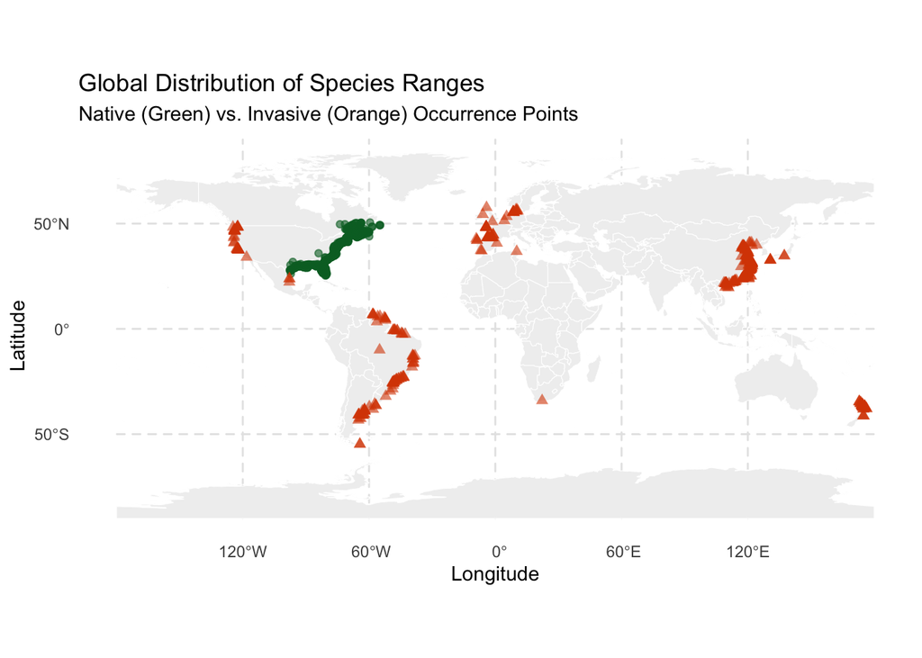

```r
# Read data
native_data <- read.csv("climaticnichedata/ecospat.native.csv")
invasive_data <- read.csv("climaticnichedata/ecospat.invasive.csv")
native_subset<-subset(native_data,native_data$sp==1)
invasive_subset<-subset(invasive_data,invasive_data$sp==1)

# Get the world map base layer
world <- ne_countries(scale = "medium", returnclass = "sf")

# Create the Map
ggplot(data = world) +
  geom_sf(fill = "#f0f0f0", color = "white") +
  geom_point(data = native_subset, aes(x = Long, y = Lat),
             color = "#006d2c",  # Vivid Green
             alpha = 0.6,        # Transparency to show density
             size = 1.5) +       # Adjust size as needed
  geom_point(data = invasive_subset, aes(x = Long, y = Lat),
             color = "#d94801",  # Vivid Orange/Red
             shape = 17,         # Triangle shape to distinguish further
             alpha = 0.6,
             size = 2) +
  labs(title = "Global Distribution of Species Ranges",
       subtitle = "Native (Green) vs. Invasive (Orange) Occurrence Points",
       x = "Longitude",
       y = "Latitude") +
  theme_minimal() +
  theme(panel.grid.major = element_line(color = "gray90", linetype = "dashed"))
```

# COUE analysis

## Read data

```r
nat<-read.csv("climaticnichedata/ecospat.native.csv") # for native range
inv<-read.csv("climaticnichedata/ecospat.invasive.csv") # for invasive range
```

These files should have the following information: longitude and latitude and their corresponding values of the 19 bioclimatic variables. The long-lat values are of the locations where the species is present and the background. An additional column (here named ‘sp’) is attached at the end to designate presence (1) and background (0) locations. Background locations are proxies for absences (pseudo-absence).

## Preparing the data

### Conducting PCA

```r
pca.env <- dudi.pca(rbind(nat,inv)[,3:21],scannf=F,nf=2)
```

**What are we doing here?**

- Principal Component Analysis (PCA) on environmental data to reduce its dimensionality, while preserving as much variance as possible.
- **`rbind(nat,inv)`**: This combines two dataframes—one representing the species’ “native” range (nat) and the other its “invasive” range (inv)—by stacking them row-wise. This ensures that the PCA is calculated based on the combined environmental space of both ranges.
- **`dudi.pca(...)`**: This is the core function from the ade4 R package used to perform the Principal Component Analysis.
- **`scannf = F`**: This argument (short for “scan number of factors”) is set to FALSE to prevent the program from opening an interactive prompt asking the user to choose the number of axes to retain.
- **`nf = 2`**: This specifies that the first two principal components (axes) should be kept. These two axes are then used to define the 2D environmental space in which the species’ niches are compared.
- **`pca.env`**: The resulting PCA object, containing information like the variable loadings and row scores, is assigned to the variable pca.env for further use.

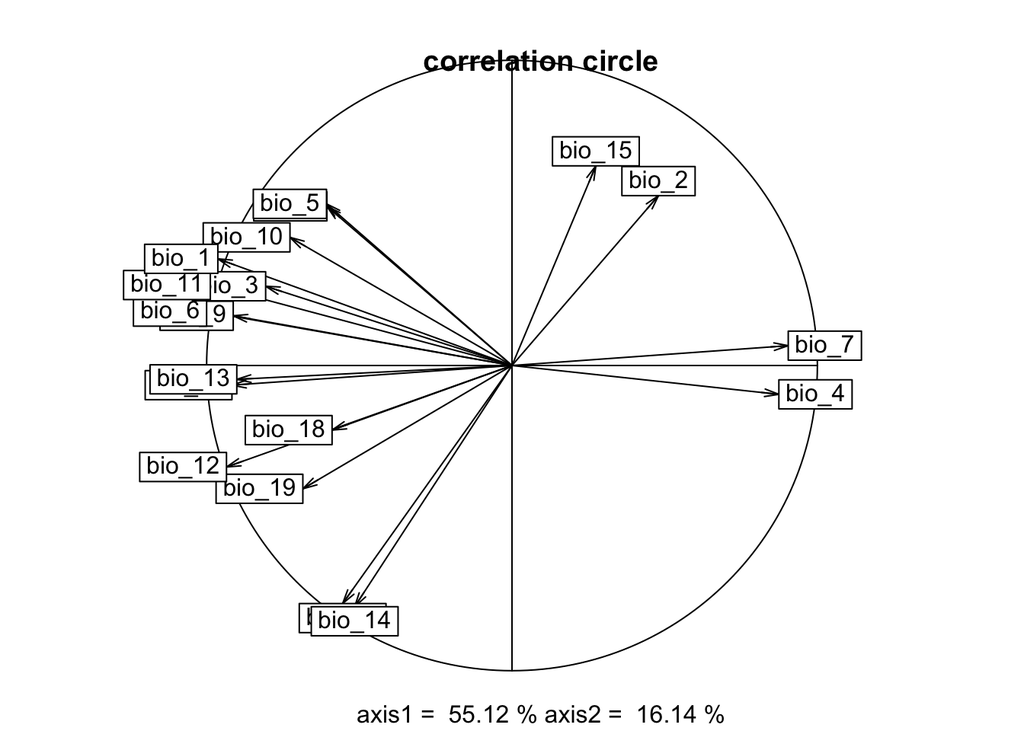

```r
ecospat.plot.contrib(contrib=pca.env$co, eigen=pca.env$eig)
```

**What are we seeing here?**

This command generates a **correlation circle** (also known as a variable contribution plot) to visualize how the original environmental variables relate to the new principal component axes.

`pca.env$co` extracts the column coordinates (or loadings) from the PCA object. These coordinates represent the correlation between the original environmental variables and the new principal component axes.

`pca.env$eig` extracts the eigenvalues of the PCA. The eigenvalues represent the amount of variance captured by each principal component. Providing this allows the function to scale or weigh the contributions correctly across different axes.

The resulting “correlation circle” typically displays arrows originating from the center (0,0):

- **Direction**: The direction of an arrow indicates which axis the variable is most strongly correlated with. For example, an arrow pointing purely right indicates a strong positive correlation with PC1.
- **Length**: The length of the arrow indicates the strength of the contribution. Longer arrows mean that variable is more important in defining the environmental space.
- **Grouping**: Arrows that are close together indicate variables that are highly correlated with each other (e.g., “Max Temperature” and “Mean Temperature”).

```r
#PCA scores for the whole study area
scores.globclim <- pca.env$li

#PCA scores for the species native distribution
scores.sp.nat <- suprow(pca.env,nat[which(nat[,22]==1),3:21])$li

#PCA scores for the species introduced distribution
scores.sp.inv <- suprow(pca.env,inv[which(inv[,22]==1),3:21])$li

# PCA scores for the whole native study area
scores.clim.nat <- suprow(pca.env,nat[,3:21])$li

# PCA scores for the whole introduced study area
scores.clim.inv <- suprow(pca.env,inv[,3:21])$li
```

**Key functions:**

`$li`: Extracts the “row coordinates” (principal component scores) from a PCA object.

`suprow()`: Projects “supplementary rows” (new data) onto an existing PCA space. This ensures that all data—whether it represents a species’ presence or the background climate—is measured on the same axes.

**Specific functions:**

`scores.globclim <- pca.env$li`: Extracts the PCA scores for the entire environmental background (the combined native and invasive study areas). This establishes the “global climate” baseline against which specific species’ niches will be compared.

`scores.sp.nat`: Filters the native dataset (`nat`) to select only rows where the species is present (column 22 equals 1). Selects the environmental variables (columns 3 to 21). Projects these specific occurrence points onto the pre-calculated PCA space (`pca.env`). Represents the **actual niche occupied** by the species in its native range.

`scores.sp.inv`: similar like above. Represents the **actual niche occupied** by the species in its invasive range.

`scores.clim.nat`: Projects all environmental points from the native study area (regardless of species presence) into the PCA space. Defines the **available climate** in the native region.

scores.clim.inv: similar like above. Defines the **available climate** in the invasive region.

### Estimating occurrence densities

```r
#Grid of the native niche
grid.clim.nat <- ecospat.grid.clim.dyn(glob=scores.globclim,
                                       glob1=scores.clim.nat,
                                       sp=scores.sp.nat, R=100,
                                       th.sp=0)

#Grid of the introduced niche
grid.clim.inv <- ecospat.grid.clim.dyn(glob=scores.globclim,
                                       glob1=scores.clim.inv,
                                       sp=scores.sp.inv, R=100,
                                       th.sp=0)
```

**What are we doing here?**

This line of code is the core step in Broennimann’s framework for niche analysis. It transforms the raw PCA points (which you calculated in the previous steps) into a **density grid** representing the species’ realized niche in its native range.

**What do the functions do?**

`ecospat.grid.clim.dyn` takes the scatter of points in the PCA space and converts them into a “heatmap” or grid. This allows us to compare niches based on **density** rather than just raw presence points.

`glob = scores.globclim`: This is the combined climate of both the native and invasive study areas. It defines the outer boundaries (extents) of the grid. By using the global background, we ensure that the Native Grid and the Invasive Grid (which we are calculating) share the exact same X and Y limits, making them mathematically comparable.

`glob1 = scores.clim.nat`: This represents the climate available specifically in the **native range**. The function uses this to calculate “environmental availability.” It ensures the model accounts for how common or rare specific climates are in the native region (removing bias).

`sp = scores.sp.nat`: These are the PCA coordinates of the species’ actual locations in the native range.

`R = 100`: This sets the grid resolution to **100x100** cells. A higher number gives a finer grid but takes more computational power.

`th.sp = 0`: This filters out species occurrences with very low density. Setting it to `0` means no filtering—every occurrence point is used to estimate the niche.

The result, `grid.clim.nat` and `grid.clim.inv` are the lists object containing matrices (Z) of the niche density. These objects are what we will pass into the overlap test functions ( `ecospat.niche.overlap`) to calculate metrics like Schoener’s D (niche overlap).

## Niche characterization

### Estimating overlap

```r
#Compute Schoener's D, index of niche overlap
D.overlap <- ecospat.niche.overlap (grid.clim.nat, grid.clim.inv, cor=T)$D
D.overlap
```

```
[1] 0.147857
```

**What are we doing here?**

This line of code calculates the **niche overlap** between the species’ native and invasive ranges using the density grids we created in the previous step.

**What do the functions do?**

`ecospat.niche.overlap` quantifies how similar the climatic niches of the two ranges are. It compares the two density grids (`grid.clim.nat` and `grid.clim.inv`) and returns a metric ranging from 0 to 1.

**`cor=T`**: This stands for “correction.” When set to `TRUE`, it corrects the overlap metric to account for the availability of environments in both ranges. This ensures that the overlap isn’t just a result of the two regions having similar climates available, but reflects the species’ actual selection of those climates.

**`$D`**: This extracts **Schoener’s D** statistic from the results.

The value stored in `D.overlap` tells us the degree of niche conservatism ([read here](https://doi.org/10.1111/j.1466-8238.2011.00659.x)):

- 0–0.2 = no or very limited overlap
- 0.2–0.4 = low overlap
- 0.4–0.6 = moderate overlap
- 0.6–0.8 = high overlap
- 0.8–1.0 = very high overlap

### Performing niche equivalency test

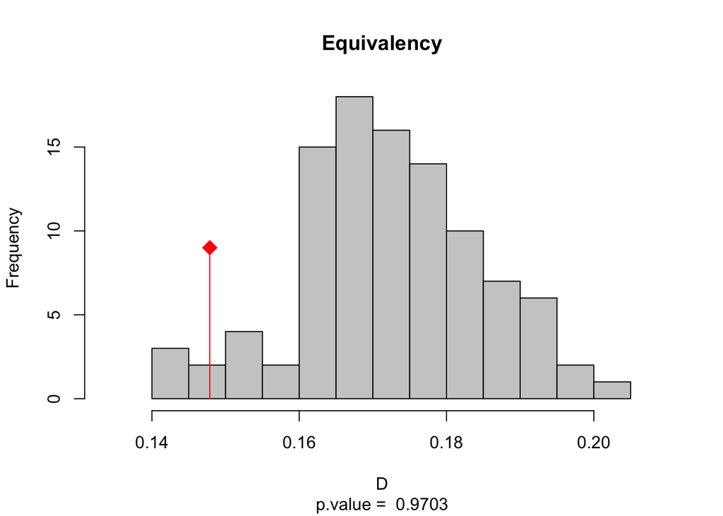

```r
#Niche equivalency test H1
#Is the overlap between the native and introduced niche higher than two random niches?
eq.test <- ecospat.niche.equivalency.test(grid.clim.nat, grid.clim.inv, rep=100)
#Plot
ecospat.plot.overlap.test(eq.test, "D", "Equivalency")
```

**What are we doing here?**

This line of code performs the **Niche Equivalency Test**, a rigorous statistical test to determine if the climatic niches of the native and invasive populations are significantly different or effectively identical.

**What do the functions do?**

`ecospat.niche.equivalency.test` compares the observed niche overlap (Schoener’s D) against a null distribution generated by randomly reallocating the occurrences between the two ranges. It tests the **null hypothesis** that the native and invasive niches are identical (i.e., any difference is just due to random chance).

H0: The realized climatic niches of the two populations (Native and Invasive) are identical.

The `eq.test` object will contain a **p-value**.

The `ecospat.plot.overlap.test` command generates a histogram to visualize the results of the Niche Equivalency Test. The resulting graph compares our actual data against random chance:

1. **The Grey Bars (Histogram):**
   - These represent the **Null Distribution**.
   - They show the range of overlap values (D) we would get if the two populations were randomly distributed (i.e., if there were no real difference between the native and invasive niches).
2. **The Red Line (Observed Value):**
   - This marks the **actual overlap (D)** calculated from our real species data.
   - **Location matters:**
     - **If the line is inside the grey bars:** Our observed overlap is “normal” or expected by chance. The niches are effectively equivalent (we cannot reject the null hypothesis that they are identical).
     - **If the line is far to the right or left (outside the bars):** Our observed overlap is significantly different from random expectation.

### Performing niche similarity test

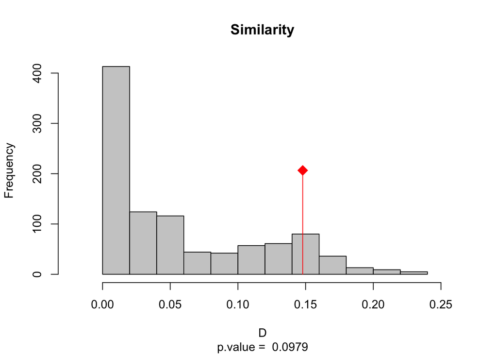

```r
#Niche similarity test H1
#Is the overlap between the native and introduced niches higher than
#when the invasive niche is randomly introduced in the introduced study area?
sim.test <- ecospat.niche.similarity.test(grid.clim.nat, grid.clim.inv,
                                          rep=1000,
                                          rand.type=2)
ecospat.plot.overlap.test(sim.test, "D", "Similarity")
```

**What are we doing here?**

This code performs the **Niche Similarity Test**, which is distinct from the Equivalency Test we did earlier. While the Equivalency Test asks “Are the niches identical?”, the Similarity Test asks “Are the niches more similar (or different) than expected, given the *different* environments available in the two regions?”

**What do the functions do?**

`ecospat.niche.similarity.test`: This tests for Niche Conservatism. It determines if the species, when introduced to a new range (invasive), is selecting climatic conditions that are similar to its native range, or if it is just occupying whatever climate happens to be available.

**`rand.type = 2`**: This is the critical argument. It specifies that the test should randomly shift the **invasive niche** within the **invasive background** (while keeping the native niche fixed). It simulates: “If this species settled randomly in the invasive region, what would the overlap look like?”

The `ecospat.plot.overlap.test` plots a histogram comparing our **observed overlap** (Schoener’s D) against the **randomized overlaps** generated by the simulation.

- **The Grey Bars (Null Hypothesis)**: This shows the amount of overlap we would get if the species was distributed randomly in the invasive range.
- **The Red Line (Observed D)**: This is the actual overlap between the native and invasive niches.

**Outcomes:**

1. **Red line to the right of the bars (Significant)**:
   - **Niche Conservatism**. The species is actively selecting environments in the invasive range that resemble its native home, significantly more than if it were just randomly spread out.
2. **Red line inside the bars (Non-significant)**:
   - The niche overlap is no different from random expectation. The species’ distribution in the new range is likely driven by availability rather than specific selection of “native-like” climates.
3. **Red line to the left of the bars (Significant)**:
   - **Niche Divergence**. The niches are *less* similar than expected by chance (the species might be actively shifting into different climates).

**If p < 0.05 (Significant)**

This means the result is **statistically significant**. You reject the null hypothesis.

- **Interpretation:** **Niche Conservatism.** The observed niche overlap is significantly **higher** than random expectation.
- **What it means biologically:** Even though the invasive region has a different climate available, the species is actively selecting the specific subset of conditions that matches its native home. It is “conserving” its niche requirements.
- **Visual:** On the plot, the red line (observed D) would be far to the **right** of the grey bars.

**If p > 0.05 (Not Significant)**

This means the result is **not statistically significant**. You cannot reject the null hypothesis.

- **Interpretation:** **Niche Shift (or Randomness).** The observed niche overlap is **not different** from what you would get if the species just settled randomly in the invasive range.
- **What it means biologically:** The species is not strictly adhering to its native climatic preferences. It might be occupying whatever environment is most abundant in the new range, or it might have shifted its niche requirements to survive in new conditions.
- **Visual:** On the plot, the red line (observed D) falls **inside** the cluster of grey bars.

### Quantifying niche dynamics

```r
niche.dyn <- ecospat.niche.dyn.index (grid.clim.nat, grid.clim.inv,intersection=0.1)
niche.dyn
```

```
$dyn
class       : SpatRaster
dimensions  : 100, 100, 1  (nrow, ncol, nlyr)
resolution  : 0.1668853, 0.1434131  (x, y)
extent      : -8.662158, 8.026375, -9.99313, 4.348185  (xmin, xmax, ymin, ymax)
coord. ref. :
source(s)   : memory
name        : lyr.1
min value   :     0
max value   :     6

$dynamic.index.w
expansion stability unfilling
0.1026096 0.8973904 0.1080284

$category_quantity
z2_only_NA  z2_only_A      z2_z1 z1_only_NA  z1_only_A      z1_z2
147.591528  22.866531 199.983266   1.624754  31.780332 262.404771
```

**What are we doing here?**

This code performs a **Niche Dynamic Analysis**.

`niche.dyn`: This function calculates the mathematical overlap between the two niches. It returns a list of metrics (Expansion, Stability, Unfilling).

- **`grid.clim.nat`** & **`grid.clim.inv`**: These are “density grids” created earlier in our workflow (using PCA scores). They represent the occupied climate space of the native and invasive populations.
- **`intersection=0.1`**: This sets a threshold (10%) to remove marginal/outlier environments, focusing the calculation on the core niche.

**What to look for in the output (`niche.dyn`):**

- **Expansion (E):** The proportion of the invasive niche that exists in climates *never* occupied in the native range. High Expansion means the species is surviving in new climates in its introduced range that it doesn’t tolerate in its native range.
- **Stability (S):** The proportion of the niche shared between both ranges. High Stability means the species is behaving predictably; it likes the same weather in its introduced range as it does at home.
- **Unfilling (U):** The proportion of the native niche that is *not* occupied in the invasive/introduced range. High Unfilling means there are climates the species likes (from home) that exist in its introduced range, but it hasn’t reached them yet (it’s likely still spreading).

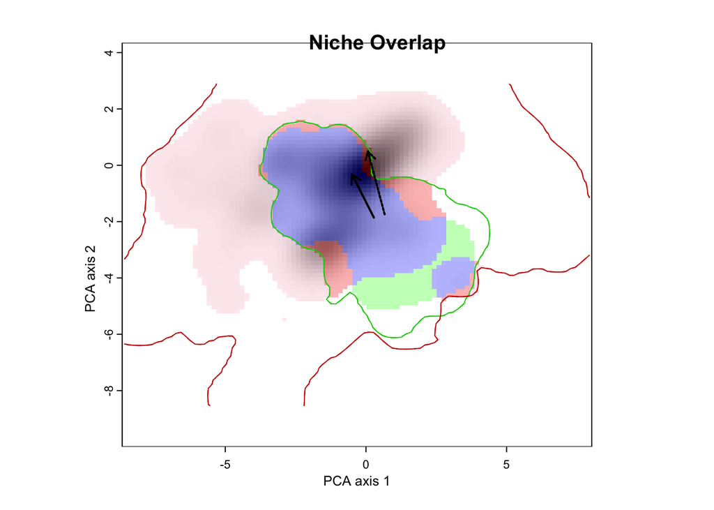

```r
ecospat.plot.niche.dyn(grid.clim.nat, grid.clim.inv, quant=0.25, interest=2,
                       title= "Niche Overlap", name.axis1="PCA axis 1",
                       name.axis2="PCA axis 2")
#colZ1=native extent
#colZ2=Introduced extent

ecospat.shift.centroids(scores.sp.nat, scores.sp.inv, scores.clim.nat,
                        scores.clim.inv,col = "black")
```

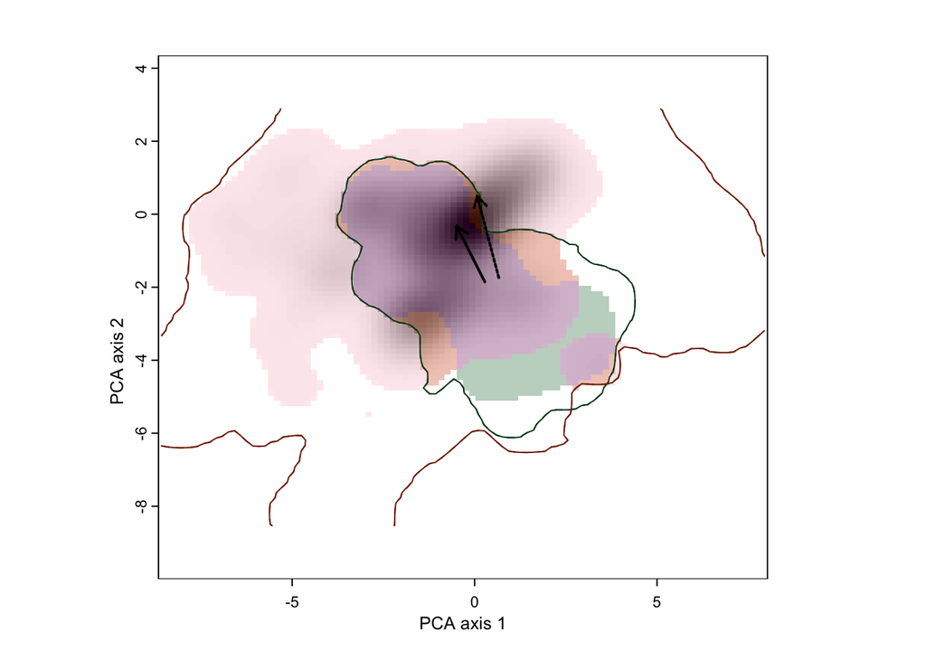

```r
# We want to add a set of different colours
ecospat.plot.niche.dyn(grid.clim.nat, grid.clim.inv, quant=0.25, interest=2,
   title= "", name.axis1="PCA axis 1", name.axis2="PCA axis 2",

   # FILLS (Use darker colors here to prevent fading)
   col.unf = "#006d2c",   # Deep Forest Green (Native)
   col.exp = "#d94801",   # Deep Orange/Red (Expansion)
   col.stab = "#7e0068",  # Deep Purple (Overlap - stands out clearly)

   # DENSITY LINES (Keep these dark for outlines)
   colZ1 = "#00441b",     # Darker Green
   colZ2 = "#7f2704")     # Darker Red

#colZ1=native extent
#colZ2=Introduced extent

ecospat.shift.centroids(scores.sp.nat, scores.sp.inv, scores.clim.nat,
                        scores.clim.inv,col = "black")
```

**What are we seeing here?**

This creates the famous “Niche Shift” plot. It visualizes the metrics calculated above on a 2D plane (PCA Axis 1 vs PCA Axis 2).

**`col.stab = "#7e0068"`:** **Stability.** This is the **Overlap**. This area represents climates where the species is found in BOTH native and introduced ranges.

**`col.unf = "#006d2c"`:** **Unfilling.** This represents climates the species occupies in its native range but **does not** occupy in its introduced range (even if that climate exists there). This suggests potential areas the species could still invade in the future.

**`col.exp = "#d94801"`:** **Expansion.** This represents climates the species occupies in its introduced range but **does not** occupy in its native range.

- **`colZ1` & `colZ2`**: These outline the *available* background climate in the Native (Z1) and Invasive (Z2) ranges (the borders of the plot).
- **`quant=0.25`**: This draws a contour line around the “core” 75% of the species density, ignoring the 25% outliers.

The arrows onto the plot show the **direction** of the shift.

- **Inputs:** It takes the raw PCA scores for the species (`sp`) and the available climate (`clim`) for both ranges.
- **What the arrows show:**
- **The “Environment” Arrow (Usually Dashed/Thinner):**
  - **What it tracks:** The center of the **Background Climate**. It connects the average climate of the Native region (entire study area) to the average climate of the Invasive region.
- **The “Species” Arrow (Usually Solid/Thicker):**
  - **What it tracks:** The center of the **Species’ Density** (where the organism is most abundant). It connects the peak density of the species in the Native range to its peak density in the Invasive range.
- **Scenario A: The Arrows are Parallel (Stability)**
  - **Visual:** Both arrows point in the same direction and have similar lengths.
  - **Interpretation:** The species is just “going with the flow.” The species’ centroid shifted only because the *available climate* shifted.
- **Scenario B: The Arrows Diverge (Expansion/Shift)**
  - **Visual:** The “Species” arrow points in a different direction than the “Environment” arrow.
  - **Interpretation:** The species is actively occupying a different part of the climate gradient in the new range, relative to what is available.

# MESS analysis

## Read data

```r
mess.data<-read.csv("climaticnichedata/mess_data.csv")
```

The data file contains occurrence locations of both native and introduced ranges and the corresponding bioclimatic variables. An additional column at the end (here named ‘sp’) has the range information.

```r
mess.data<-mess.data[c(1:21)]
```

## Preparing data

```r
#Defining projection and calibration data sets
proj<- mess.data[1:538,] #Projection data set (introduced range)
cal<-mess.data[538:1421,] #Calibration data set (native range)
```

## Analysis

```r
mess.object<-ecospat.mess(proj,cal,w="default")
```

Plot

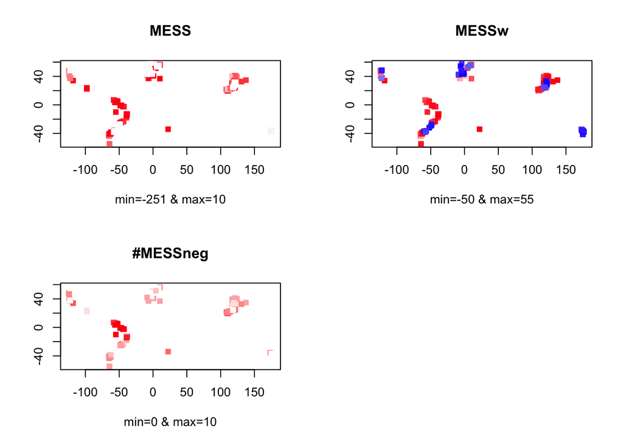

```r
ecospat.plot.mess(mess.object = mess.object)
```

**What are we seeing here?**

Three plots are generated

- MESS plot pixels in red indicate sites where at least one environmental predictor has values outside of the range of that predictor in the calibration data set.
- In the MESSw plot, same as previous plot but with weighted by the number of predictors.
- The MESSneg plot shows at each site how many predictors have values outside of their calibration range.

In a nutshell, a MESS analysis produces a map with a scale of positive and negative values:

- **Positive Values (Blue/Green):** **High Similarity.** The climate in this part of the introduced range is well-represented in our native training data. **We can trust the model predictions here.**
- **Negative Values (Red):** **Novel Environment.** At least one environmental variable (e.g., Max Temperature) is outside the range of values seen in the training data. The more negative the value, the more dissimilar the environment. **Model predictions here are unreliable.**